# ggplot2: To Publication

Lecture 06a  
POLS 6394 · Tuesday, September 29

## Today

- Titles, captions, axis names, and themes
- Small multiples: one comparable panel per group
- The `scales` package: readable values, breaks, and transforms
- Color palettes and highlighting one case
- Reference lines, direct labels, and saving figures
- Lab: start the cigarette makeover

## Setup

Run this chunk as written. The files are bundled with this lesson.

```r
library(tidyverse)
library(scales)
library(ggrepel)
cigarettes <- read_csv("Data/cigarettes/cigarette.csv", show_col_types = FALSE) |>
  select(-rownames) |>
  mutate(real_tax = tax / cpi,
         date = make_date(year))
gap_2007 <- read_csv("Data/gapminder/gapminder.csv", show_col_types = FALSE) |>
  filter(year == 2007)
states_2000 <- read_csv("Data/state_policy/cspp_states.csv", show_col_types = FALSE) |>
  filter(year == 2000)
```

`scales` supplies the label formatters and `ggrepel` places text labels that don’t collide. `real_tax` divides the nominal tax by the consumer price index, so taxes from different years are comparable. `make_date(year)`, from 05a, stores each year as a real `Date` (January 1 of that year) for date axes.

## Sample 10 countries

The fixed seed makes this random sample the same when we render again.

```r
set.seed(6394)
gap_2007 |> slice_sample(n = 10)
```

```
# A tibble: 10 × 6
   country      continent  year lifeExp      pop gdpPercap
   <chr>        <chr>     <dbl>   <dbl>    <dbl>     <dbl>
 1 Somalia      Africa     2007    48.2  9118773      926.
 2 Philippines  Asia       2007    71.7 91077287     3190.
 3 Taiwan       Asia       2007    78.4 23174294    28718.
 4 Sweden       Europe     2007    80.9  9031088    33860.
 5 Algeria      Africa     2007    72.3 33333216     6223.
 6 Mongolia     Asia       2007    66.8  2874127     3096.
 7 Togo         Africa     2007    58.4  5701579      883.
 8 Uganda       Africa     2007    51.5 29170398     1056.
 9 Sierra Leone Africa     2007    42.6  6144562      863.
10 Zambia       Africa     2007    42.4 11746035     1271.
```

## Sample 10 state-years

```r
set.seed(6394)
states_2000 |> slice_sample(n = 10) |>
  select(state, region.name, pid, ideo, pollib_median)
```

```
# A tibble: 10 × 5
   state          region.name   pid  ideo pollib_median
   <chr>          <chr>       <dbl> <dbl>         <dbl>
 1 New Jersey     northeast    0.1  -0.04           2.1
 2 Rhode Island   northeast    0.22 -0.05           1.8
 3 Arizona        west        -0.08 -0.1           -0.7
 4 Maine          northeast   -0.04 -0.01           1
 5 Alabama        south        0.09 -0.19          -1.8
 6 Delaware       south       -0.07 -0.05           0.5
 7 North Carolina south        0.01 -0.23          -1.4
 8 Colorado       west        -0.07 -0.05          -0.4
 9 Louisiana      south        0.12 -0.21          -1
10 West Virginia  south        0.28  0.01           0.2
```

## Sample 10 cigarette records

A cigarette row is one state-year, 48 states from 1985 to 1995: packs per capita (`packpc`), the nominal tax in cents (`tax`), and the consumer price index (`cpi`).

```r
set.seed(6394)
cigarettes |> slice_sample(n = 10)
```

```
# A tibble: 10 × 11
   state  year   cpi    pop packpc income   tax avgprs  taxs real_tax date
   <chr> <dbl> <dbl>  <dbl>  <dbl>  <dbl> <dbl>  <dbl> <dbl>    <dbl> <date>
 1 NY     1995  1.52 1.82e7   70.8 5.03e8  80     222.  88.5     52.5 1995-01-01
 2 CT     1987  1.14 3.25e6  107.  7.11e7  42     137.  52.1     37.0 1987-01-01
 3 WI     1992  1.40 5.00e6   94.5 9.95e7  51.3   193.  60.5     36.6 1992-01-01
 4 IL     1990  1.31 1.14e7   96.0 2.38e8  46.0   160.  55.1     35.2 1990-01-01
 5 AL     1990  1.31 4.05e6  112.  6.41e7  32.5   143.  33.8     24.9 1990-01-01
 6 NE     1987  1.14 1.57e6  105.  2.36e7  39     122.  43.7     34.3 1987-01-01
 7 OR     1995  1.52 3.14e6   92.2 7.12e7  62     190.  62       40.7 1995-01-01
 8 MN     1995  1.52 4.61e6   82.9 1.13e8  72     220.  86.4     47.2 1995-01-01
 9 CA     1992  1.40 3.09e7   66.4 7.02e8  55     218.  69.3     39.2 1992-01-01
10 AL     1993  1.45 4.19e6  105.  7.54e7  38.5   165.  40.0     26.6 1993-01-01
```

# Titles and captions

## `labs()` names the text on a plot

In 05b, `labs()` gave the histogram readable axis titles. It also sets the title, subtitle, caption, and legend titles (`color =`, `fill =`). Leave an argument out to keep the default; `NULL` removes it.

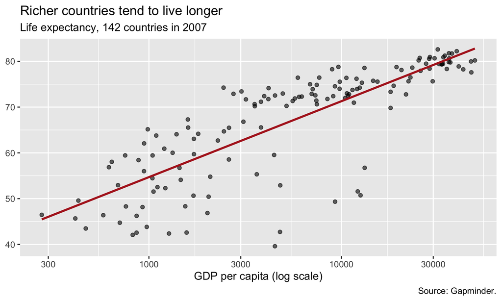

```r
ggplot(gap_2007, aes(x = gdpPercap, y = lifeExp)) +
  geom_point(alpha = 0.6) +
  geom_smooth(method = "lm", formula = y ~ x,
              se = FALSE, color = "firebrick") +
  scale_x_log10() +
  labs(
    title = "Richer countries tend to live longer",
    subtitle =
      "Life expectancy, 142 countries in 2007",
    x = "GDP per capita (log scale)", y = NULL,
    caption = "Source: Gapminder."
  )
```

## Titles that state the finding

Readers usually look at the title first. It can say what the figure shows rather than repeat the axis names.

- Descriptive: *“Life expectancy by GDP per capita”*
- Assertive: *“Richer countries tend to live longer”*

Put the main finding in the title, details about the data in the subtitle, and the source in the caption.

## The source caption

Name the data source in the caption. Discuss important limitations in the paper text or appendix, where you have room to explain them.

```r
labs(caption = "Source: state cigarette panel, 1985–1995 (Stock and Watson).")
```

# Themes

## Why use a theme?

A theme settles most of the decisions about fonts, gridlines, margins, and background. We can start with a built-in theme, change what we need, and use it throughout a paper.

Themes change the frame around the data. Color palettes decide which colors represent the data.

## Built-in themes

Complete themes set the non-data parts of a plot in one call. `theme_minimal()` and `theme_bw()` are good starting points for papers.

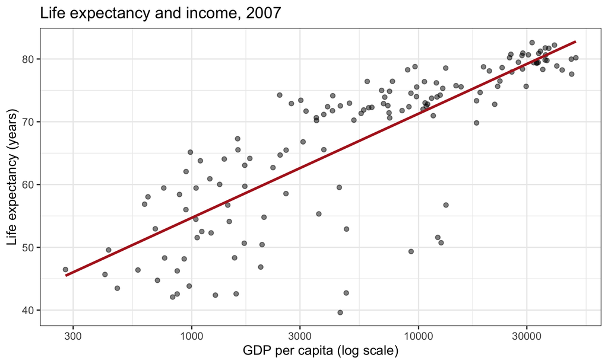

```r
p <- ggplot(gap_2007,
            aes(x = gdpPercap, y = lifeExp)) +
  geom_point(alpha = 0.5) +
  geom_smooth(method = "lm", formula = y ~ x,
              se = FALSE, color = "firebrick") +
  scale_x_log10() +
  labs(title = "Life expectancy and income, 2007",
       x = "GDP per capita (log scale)",
       y = "Life expectancy (years)")

p + theme_bw()
```

## Dark mode and a publication style

A dark background needs light points and a brighter fitted line. `theme_dark()` supplies the frame; the Economist style comes from `ggthemes`. Both plots use the same data and fit.

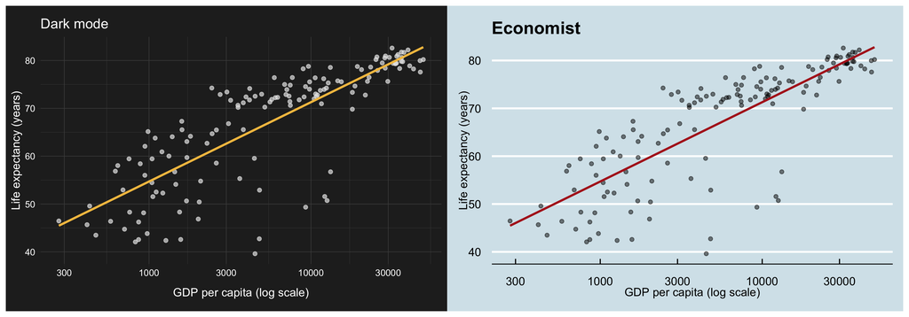

The same data in dark mode and an Economist-style theme.

## A typography-first theme

`hrbrthemes::theme_ipsum()` puts more emphasis on type. `base_family = "sans"` avoids requiring a special font.

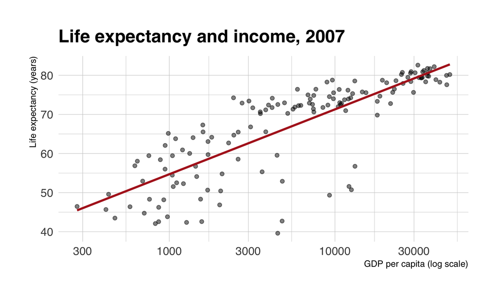

```r
p + hrbrthemes::theme_ipsum(base_family = "sans")
```

## A class theme in a few lines

Our class theme starts with `theme_bw()` and changes just a few settings. `element_text()` sets text properties: `face = "bold"` bolds the title, `size = rel(1.1)` makes it 10% larger than the base text, and `hjust = 0.5` centers it. `legend.position = "bottom"` moves legends below the plot.

```r
theme_class <- function(base_size = 13) {
  theme_bw(base_size = base_size) +
    theme(
      plot.title = element_text(face = "bold", size = rel(1.1), hjust = 0.5),
      plot.subtitle = element_text(hjust = 0.5),
      plot.title.position = "plot",
      legend.position = "bottom"
    )
}
```

## Set it once

`theme_set()` makes the class theme the default for every later plot in this R session.

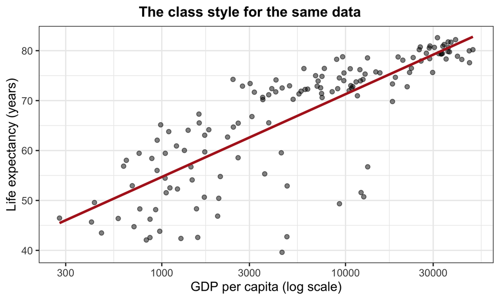

```r
theme_set(theme_class())
p + labs(title = "The class style for the same data")
```

# Small multiples

## Why split a plot into panels?

In 05b, color and shape distinguished regions on one scatterplot. **Small multiples** give each region its own panel, so we can see patterns within each region.

Shared axes let us compare regions. Each panel contains a subset of the same states.

## Panel labels

The name above each panel identifies the group of states shown there. The source uses lowercase region names. We capitalize them in `states_plot` so the panels read “South” and “West”.

`labs(x = ..., y = ...)` names the axes shared by the panels. To change the panel names, change the values of the faceting variable before plotting.

## `facet_wrap()` for one variable

`facet_wrap(~ region.name)` makes one panel per region; `ncol = 2` arranges them in two columns (`nrow` sets rows instead). The `~` introduces the faceting variable; it does not fit a regression. Each panel holds only its region’s states, on shared axes.

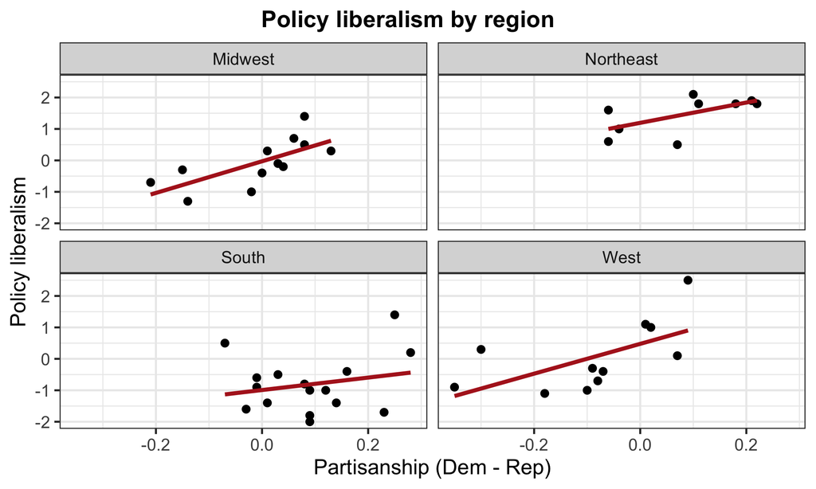

```r
states_plot <- states_2000 |>
  drop_na(pid, pollib_median) |>
  mutate(region.name = str_to_title(region.name))
ggplot(states_plot, aes(x = pid, y = pollib_median)) +
  geom_point() +
  geom_smooth(method = "lm", formula = y ~ x,
              se = FALSE, color = "firebrick") +
  facet_wrap(~ region.name, ncol = 2) +
  labs(title = "Policy liberalism by region",
       x = "Partisanship (Dem - Rep)",
       y = "Policy liberalism")
```

## Shared or separate y-axes?

By default, `scales = "fixed"` gives every panel the same axis ranges. Equal heights then mean equal policy scores. `scales = "free_y"` gives each panel its own y-axis, so check the axis labels before comparing heights.

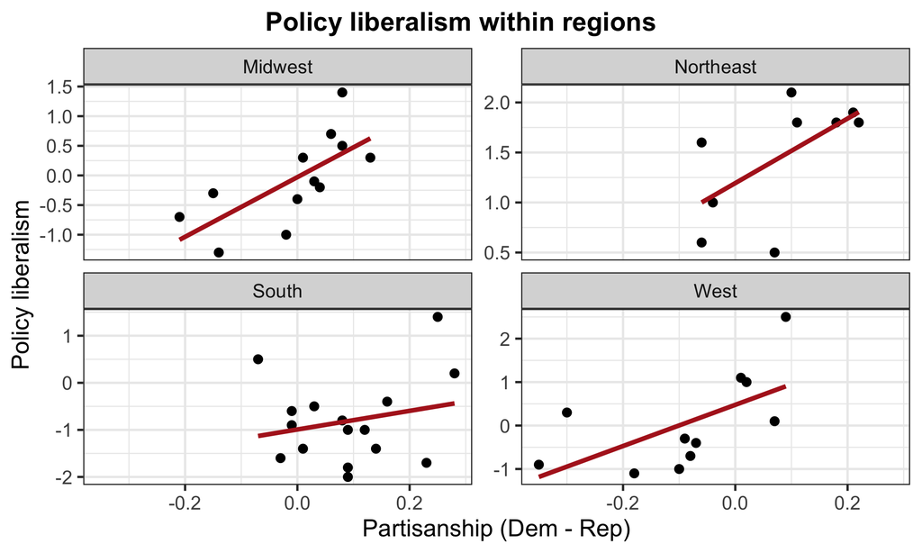

```r
ggplot(states_plot, aes(x = pid, y = pollib_median)) +
  geom_point() +
  geom_smooth(method = "lm", formula = y ~ x,
              se = FALSE, color = "firebrick") +
  facet_wrap(~ region.name, ncol = 2,
             scales = "free_y") +
  labs(title = "Policy liberalism within regions",
       x = "Partisanship (Dem - Rep)",
       y = "Policy liberalism")
```

## Order the panels

Panels follow the facet variable’s factor levels. `fct_reorder()` from 05a orders regions by median policy score, so the panels run South, West, Midwest, Northeast. The points and fitted lines stay the same.

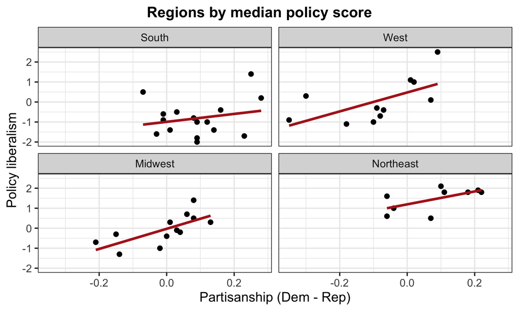

```r
states_ordered <- states_plot |>
  mutate(region_ordered =
           fct_reorder(region.name, pollib_median))
ggplot(states_ordered, aes(x = pid, y = pollib_median)) +
  geom_point() +
  geom_smooth(method = "lm", formula = y ~ x,
              se = FALSE, color = "firebrick") +
  facet_wrap(~ region_ordered, ncol = 2) +
  labs(title = "Regions by median policy score",
       x = "Partisanship (Dem - Rep)",
       y = "Policy liberalism")
```

## `facet_grid()` for two variables

`facet_grid(rows ~ columns)` crosses two variables: party lean in rows, region in columns. `if_else()` is the two-way version of 05a’s `case_when()`: where `pid > 0` it returns “Dem”, otherwise “Rep”. Some panels hold only a few states, so we show the observations without fitting separate lines.

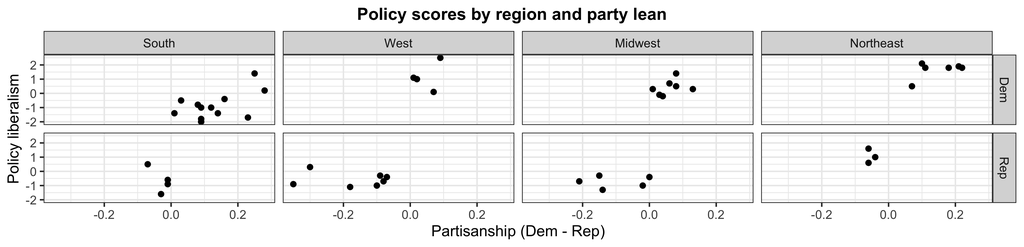

```r
states_grid <- states_ordered |>
  mutate(party_lean = if_else(pid > 0, "Dem", "Rep"))
ggplot(states_grid, aes(x = pid, y = pollib_median)) +
  geom_point() +
  facet_grid(party_lean ~ region_ordered) +
  labs(title = "Policy scores by region and party lean",
       x = "Partisanship (Dem - Rep)", y = "Policy liberalism")
```

## Which layout fits?

| Question | Facet choice |
| --- | --- |
| One grouping variable | `facet_wrap(~ region.name)` |
| Two grouping variables | `facet_grid(party_lean ~ region_ordered)` |

Use shared scales for comparisons *between* panels. Free a scale when the range hides the pattern *within* a panel, and label the axes clearly. Order the facet variable before plotting when panel order carries meaning.

Compare with 05b’s single colored plot: which view makes within-region patterns easier to inspect, and which helps compare individual states across regions?

# The scales package

## One number, several views

`scales` supplies functions for printing values on axes and legends. `label_number(accuracy = 0.001)` creates a formatting function; `(rate)` calls it on a test value. In a plot, ggplot supplies the tick values when you pass the formatter to `labels =`.

```r
rate <- 0.12346
label_number(accuracy = 0.001)(rate)
```

```
[1] "0.123"
```

```r
label_percent(accuracy = 0.1)(rate)
```

```
[1] "12.3%"
```

```r
label_dollar(accuracy = 0.01)(rate)
```

```
[1] "$0.12"
```

The same value reads as `0.123`, `12.3%`, or `$0.12`. Only one of these makes sense for a given variable.

## Control the printed precision

`accuracy` sets the rounding of the *label*, not the stored data. `label_comma()` groups thousands; `label_number(scale_cut = cut_short_scale())` abbreviates large values.

```r
values <- c(1234.567, 1250000)
label_number(accuracy = 0.1, big.mark = ",")(values)
```

```
[1] "1,234.6"     "1,250,000.0"
```

```r
label_comma(accuracy = 1)(values)
```

```
[1] "1,235"     "1,250,000"
```

```r
label_number(scale_cut = cut_short_scale())(values)
```

```
[1] "1K" "1M"
```

```r
values
```

```
[1]    1234.567 1250000.000
```

Keep enough digits to distinguish observations. Rounding the displayed axis is different from rounding the data before analysis.

## Axis values with `scales`

`labs(x = ...)` names the axis. `labels = label_dollar(accuracy = 1)` prints dollar signs on its ticks without changing the data. The log scale spreads out lower GDP values. A loess smoother follows the local pattern; unlike the straight `lm` line from 05b, it can bend.

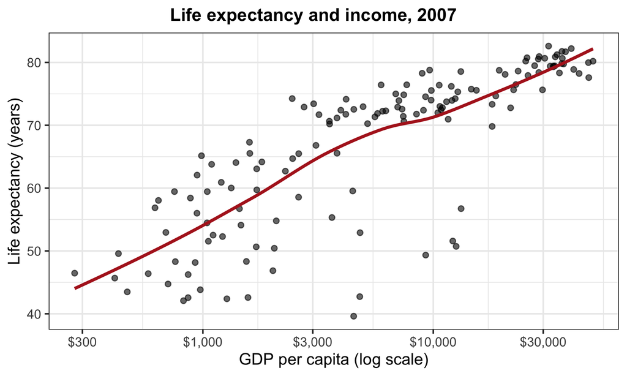

```r
ggplot(gap_2007, aes(x = gdpPercap, y = lifeExp)) +
  geom_point(alpha = 0.6) +
  geom_smooth(method = "loess", formula = y ~ x,
              se = FALSE, color = "firebrick") +
  scale_x_log10(labels = label_dollar(accuracy = 1)) +
  labs(title = "Life expectancy and income, 2007",
       x = "GDP per capita (log scale)",
       y = "Life expectancy (years)")
```

## The `scale_` naming rule

Every scale function is named the same way: `scale_` + the **aesthetic** + the **kind of variable**.

| Function | Controls |
| --- | --- |
| `scale_x_continuous()` | a continuous x-axis |
| `scale_y_continuous()` | a continuous y-axis |
| `scale_x_discrete()` | a categorical x-axis |

Anything you can do to `x` you can do to `y`, with the same arguments.

## Transforms and color scales

The same naming pattern covers common transforms and color:

| Function | Controls |
| --- | --- |
| `scale_x_log10()`, `scale_x_date()` | a log or date x-axis |
| `scale_color_manual()` | point and line colors chosen by you |
| `scale_fill_viridis_c()` | a continuous fill palette |

Color is a scale, too. Later we’ll choose a palette with the same `scale_` pattern.

## Year stored as a number

This plot uses the numeric `year` column. ggplot puts ticks at 1987.5 and 1992.5, though the data contain one observation per whole year. Even an integer column gets a continuous axis; those half-years are axis labels, not observations.

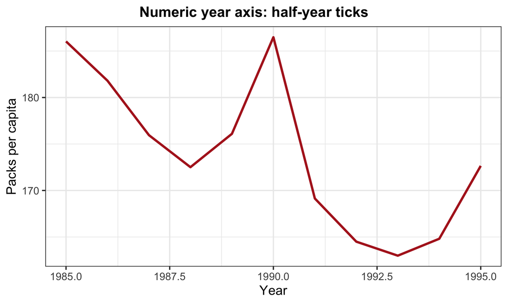

```r
cigarettes |>
  filter(state == "KY") |>
  ggplot(aes(x = year, y = packpc)) +
  geom_line(color = "firebrick", linewidth = 1.1) +
  labs(title = "Numeric year axis: half-year ticks",
       x = "Year", y = "Packs per capita")
```

## Years as dates

The setup chunk also made `date = make_date(year)`, using January 1 of each year. `scale_x_date()` lets us request calendar breaks every two years and print them with `%Y`. A numeric year can work if you set whole-year breaks explicitly, but dates are more convenient when the plot uses calendar time.

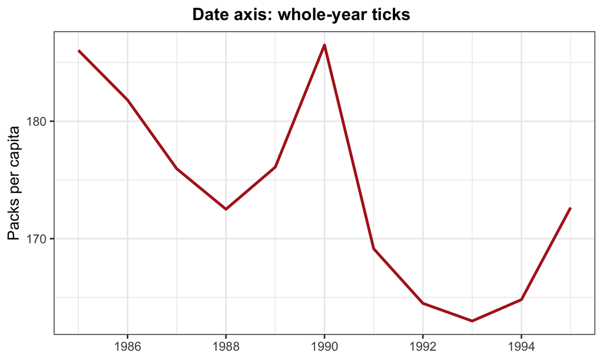

```r
cigarettes |>
  filter(state == "KY") |>
  ggplot(aes(x = date, y = packpc)) +
  geom_line(color = "firebrick", linewidth = 1.1) +
  scale_x_date(date_breaks = "2 years",
               date_labels = "%Y") +
  labs(title = "Date axis: whole-year ticks",
       x = NULL, y = "Packs per capita")
```

## When the x-axis is a date

In 05a, we parsed hearing dates. When a column is a real `Date`, `scale_x_date()` places calendar breaks and formats their labels. Here we use monthly breaks instead of the yearly breaks above.

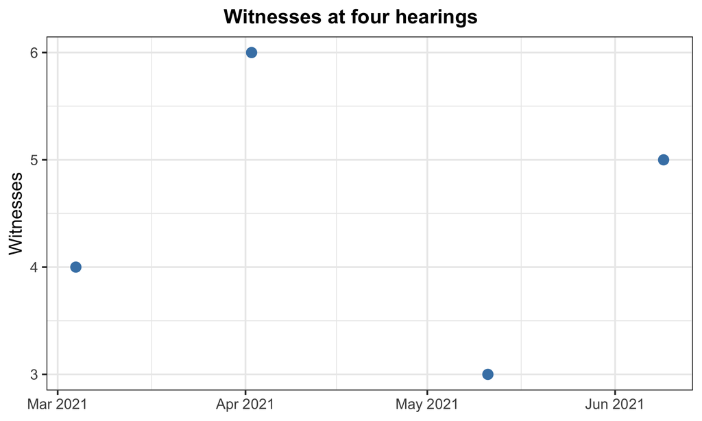

```r
hearings <- tibble(
  date = lubridate::ymd(c("2021-03-04", "2021-04-02",
                          "2021-05-11", "2021-06-09")),
  witnesses = c(4, 6, 3, 5)
)

ggplot(hearings, aes(x = date, y = witnesses)) +
  geom_point(size = 3, color = "steelblue") +
  scale_x_date(date_breaks = "1 month",
               date_labels = "%b %Y") +
  labs(title = "Witnesses at four hearings",
       x = NULL, y = "Witnesses")
```

## Date label codes

`date_labels` uses short codes for date parts. For March 2021:

| Code | Prints |
| --- | --- |
| `%b` | `Mar` (abbreviated month) |
| `%B` | `March` (full month) |
| `%m` | `03` (month number) |
| `%y` | `21` (two-digit year) |
| `%Y` | `2021` (four-digit year) |

The plot uses `%b %Y`, so its label reads `Mar 2021`. Use `%b %y` when the shorter `Mar 21` is clear enough.

## Powers-of-ten breaks

ggplot’s automatic GDP ticks include $300 and $3,000. I prefer powers of ten as the starting point, so here I request $1,000 and $10,000. Add intermediate ticks only when they help answer the question.

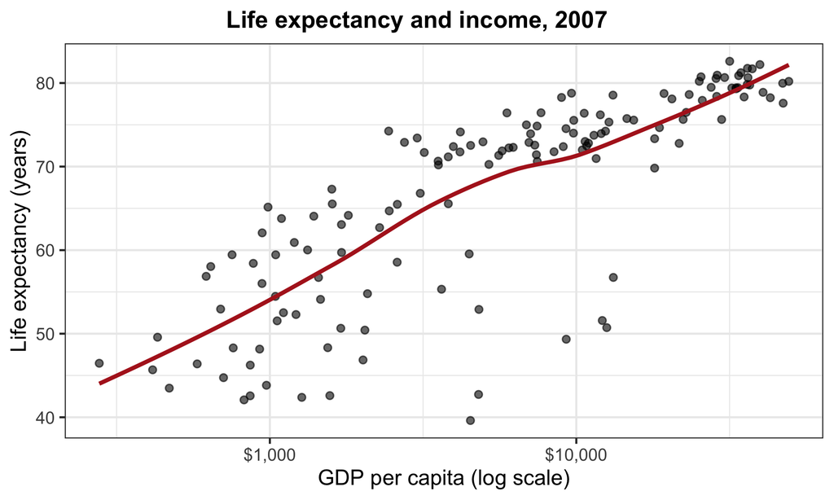

```r
ggplot(gap_2007, aes(x = gdpPercap, y = lifeExp)) +
  geom_point(alpha = 0.6) +
  geom_smooth(method = "loess", formula = y ~ x,
              se = FALSE, color = "firebrick") +
  scale_x_log10(breaks = 10^(3:4),
                labels = label_dollar(accuracy = 1)) +
  scale_y_continuous(breaks = seq(40, 80, 10)) +
  labs(title = "Life expectancy and income, 2007",
       x = "GDP per capita (log scale)",
       y = "Life expectancy (years)")
```

## `limits` throws data away

A scale’s `limits` argument does **not** zoom. It drops every row outside the range before anything else happens — including before the smoother is fit.

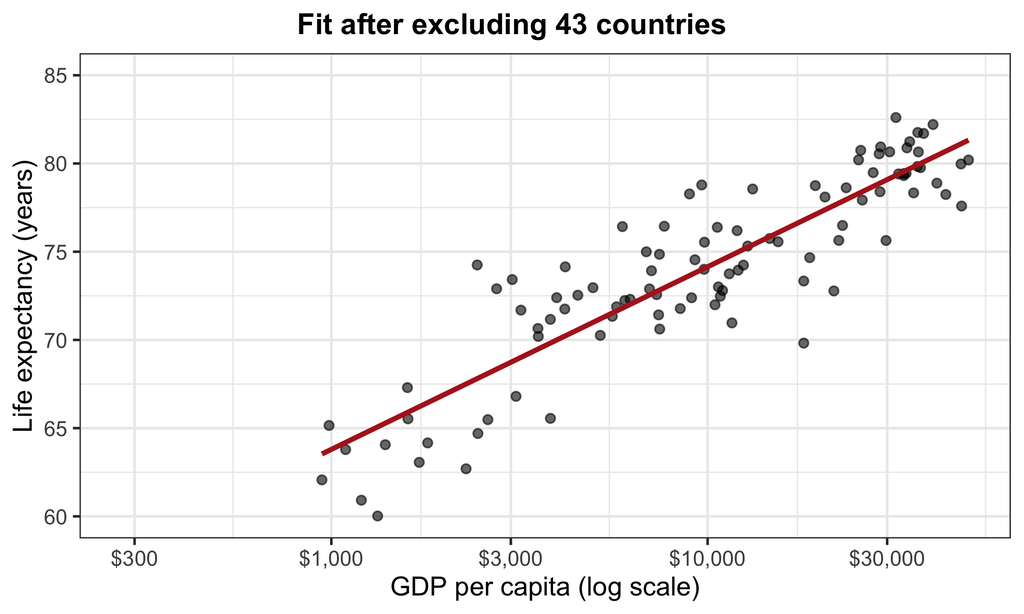

```r
ggplot(gap_2007, aes(x = gdpPercap, y = lifeExp)) +
  geom_point(alpha = 0.6) +
  geom_smooth(method = "lm", formula = y ~ x,
              se = FALSE, color = "firebrick") +
  scale_x_log10(labels = label_dollar(accuracy = 1)) +
  scale_y_continuous(limits = c(60, 85)) +
  labs(title = "Fit after excluding 43 countries",
       x = "GDP per capita (log scale)",
       y = "Life expectancy (years)")
```

## A limit changes the fit

The scale limit drops 43 of the 142 countries before the smoother is fitted. The fitted slope falls from 16.6 to 10.3. ggplot warns that it removed rows, but the plot alone does not tell you how the fit changed.

## `coord_cartesian()` zooms

To crop the view while keeping all observations in the fit, set the window with `coord_cartesian()`.

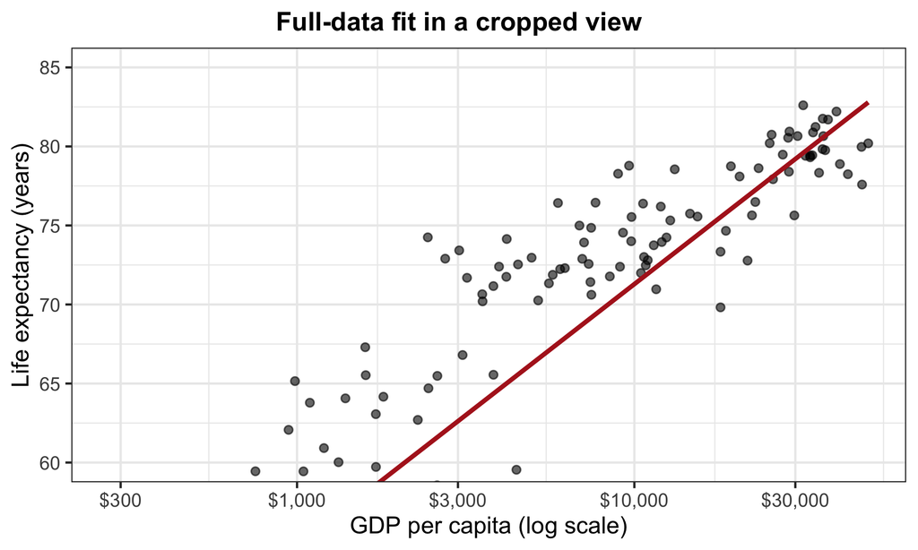

```r
ggplot(gap_2007, aes(x = gdpPercap, y = lifeExp)) +
  geom_point(alpha = 0.6) +
  geom_smooth(method = "lm", formula = y ~ x,
              se = FALSE, color = "firebrick") +
  scale_x_log10(labels = label_dollar(accuracy = 1)) +
  coord_cartesian(ylim = c(60, 85)) +
  labs(title = "Full-data fit in a cropped view",
       x = "GDP per capita (log scale)",
       y = "Life expectancy (years)")
```

Rule of thumb: **`limits` to exclude cases on purpose, `coord_cartesian()` to zoom.**

## Short labels for population

Population runs into the millions and billions. `cut_short_scale()` lets `label_number()` print `10M` instead of `10,000,000`. The default log-axis ticks remain powers of ten; we set the y-axis breaks every 10 years.

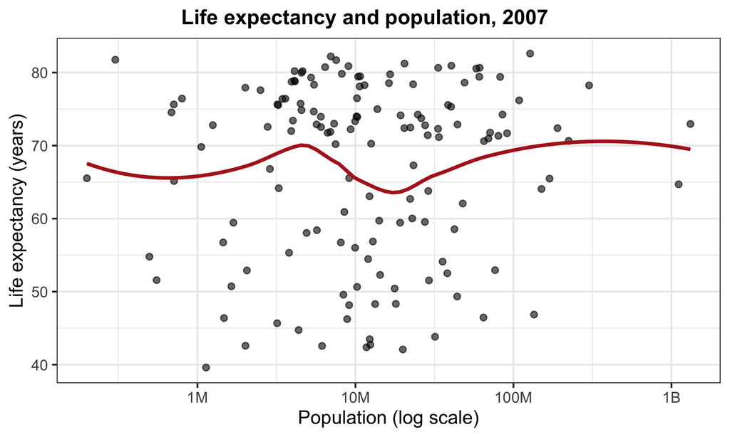

```r
ggplot(gap_2007, aes(x = pop, y = lifeExp)) +
  geom_point(alpha = 0.6) +
  geom_smooth(method = "loess", formula = y ~ x,
              se = FALSE, color = "firebrick") +
  scale_x_log10(
    labels = label_number(scale_cut = cut_short_scale())
  ) +
  scale_y_continuous(breaks = seq(40, 80, 10)) +
  labs(title = "Life expectancy and population, 2007",
       x = "Population (log scale)",
       y = "Life expectancy (years)")
```

# Color palettes

## Why choose a palette?

A palette assigns colors to data values. If several figures show the same groups, keep their colors consistent. A theme sets the surrounding frame; a palette colors the data.

First decide whether color represents categories, increasing values, or departures from a midpoint. Then pick a palette from the matching family.

The palette examples show points alone so we can compare the color mappings without fitted lines.

## Three color families

Match the palette to the variable:

- **Qualitative** — unordered categories (continents, parties). Hues differ, no order implied.
- **Sequential** — ordered low → high. One hue, varying lightness.
- **Diverging** — a meaningful midpoint (above / below zero). Two hues meeting at neutral.

## Categories: ColorBrewer

Continents have no natural order. `scale_color_brewer(palette = "Set2")` gives them distinct hues without suggesting a ranking.

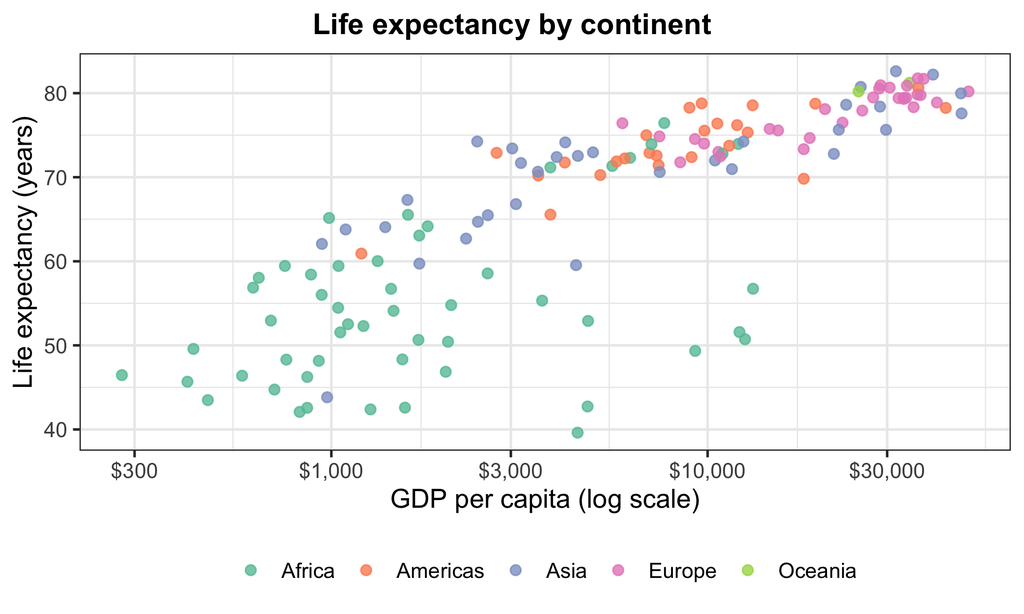

```r
ggplot(gap_2007,
       aes(x = gdpPercap, y = lifeExp,
           color = continent)) +
  geom_point(alpha = 0.8, size = 2) +
  scale_x_log10(labels = label_dollar(accuracy = 1)) +
  scale_color_brewer(palette = "Set2") +
  labs(title = "Life expectancy by continent",
       x = "GDP per capita (log scale)",
       y = "Life expectancy (years)",
       color = NULL)
```

## Ordered values: viridis

State ideology varies continuously. `scale_color_viridis_c(option = "plasma")` maps its low and high values to a continuous sequence. The `_c` means continuous.

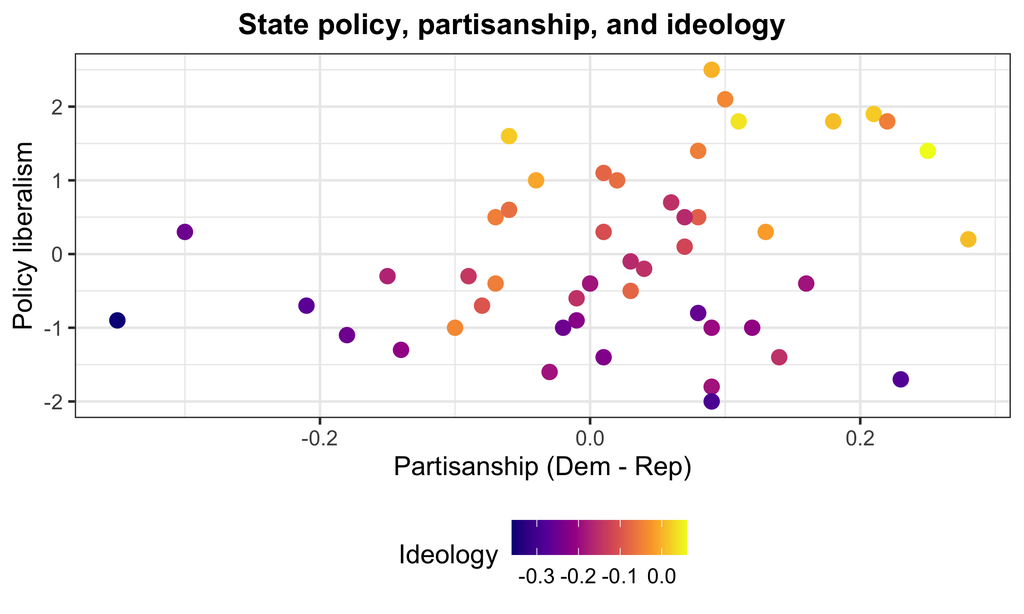

```r
states_palette <- states_2000 |>
  drop_na(pid, pollib_median, ideo)
ggplot(states_palette,
       aes(x = pid, y = pollib_median, color = ideo)) +
  geom_point(size = 3) +
  scale_color_viridis_c(option = "plasma") +
  labs(title =
         "State policy, partisanship, and ideology",
       x = "Partisanship (Dem - Rep)",
       y = "Policy liberalism", color = "Ideology")
```

## A real midpoint: above or below average

Each bar shows a continent’s mean life expectancy minus the overall country mean. Zero has a clear meaning: the continent is at the overall mean. Diverging colors distinguish values above and below it.

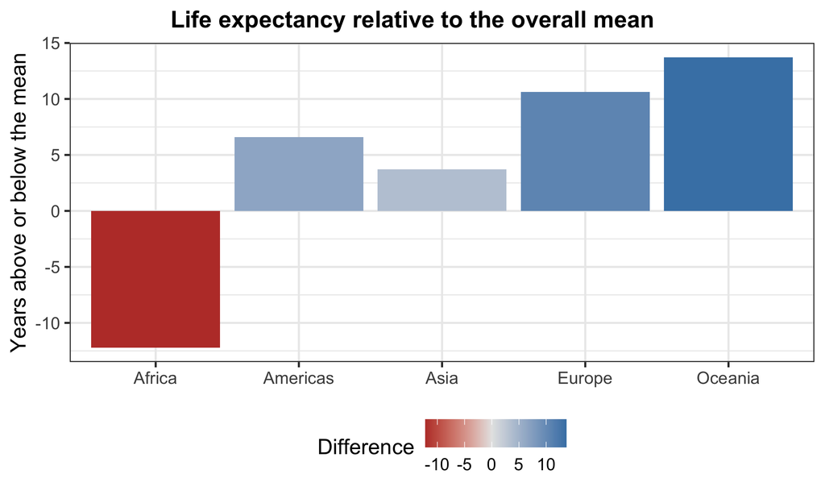

```r
life_by_continent <- gap_2007 |>
  group_by(continent) |>
  summarize(mean_life = mean(lifeExp)) |>
  mutate(difference =
           mean_life - mean(gap_2007$lifeExp))

ggplot(life_by_continent,
       aes(x = continent, y = difference,
           fill = difference)) +
  geom_col() +
  scale_fill_gradient2(low = "firebrick",
                       mid = "gray90",
                       high = "steelblue",
                       midpoint = 0) +
  labs(title =
         "Life expectancy relative to the overall mean",
       x = NULL, y = "Years above or below the mean",
       fill = "Difference")
```

## Highlight one state

With 48 states, a 48-color legend is hard to read. If we care about one state, show the others in gray and color that state.

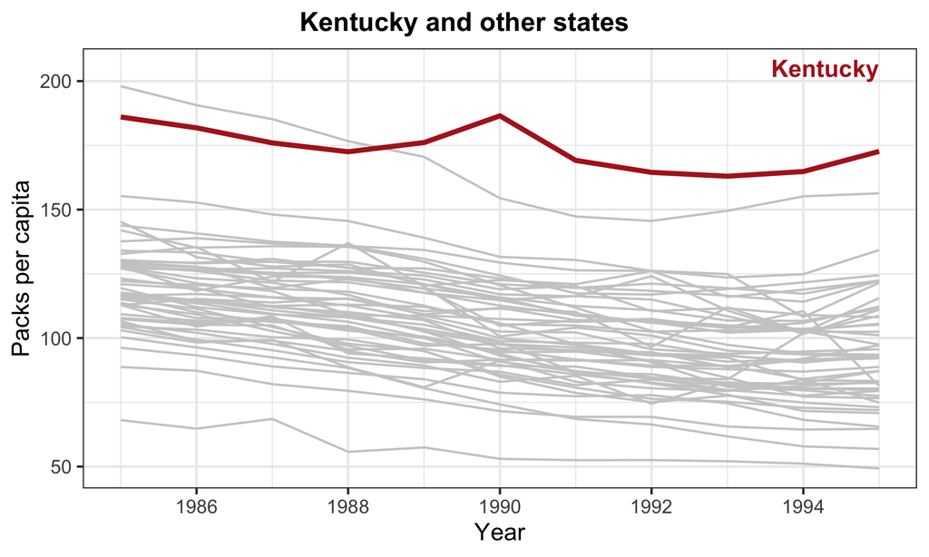

```r
ggplot(cigarettes,
       aes(x = date, y = packpc, group = state)) +
  geom_line(color = "gray80") +
  geom_line(
    data = filter(cigarettes, state == "KY"),
    color = "firebrick", linewidth = 1.3
  ) +
  annotate("text", x = make_date(1995), y = 205,
           label = "Kentucky", color = "firebrick",
           fontface = "bold", hjust = 1) +
  scale_x_date(date_breaks = "2 years",
               date_labels = "%Y") +
  labs(title = "Kentucky and other states",
       x = "Year", y = "Packs per capita")
```

## Your Turn: find and highlight one state

*~3 minutes.*

First, find the state with the highest `packpc` in 1995. The second filter compares `packpc` to its maximum; `pull(state)` returns the abbreviation. Then highlight that state’s line in steelblue.

```r
# Fill in, then delete the eval:false line and re-render.
top_state <- cigarettes |>
  filter(year == 1995) |>
  filter(packpc == ___) |>
  pull(state)

ggplot(cigarettes, aes(x = date, y = packpc, group = state)) +
  geom_line(color = "gray80") +
  geom_line(data = filter(cigarettes, state == ___),
            color = "steelblue", linewidth = 1.3) +
  scale_x_date(date_breaks = "2 years",
               date_labels = "%Y") +
  labs(title = "Highest-consumption state in 1995",
       x = "Year", y = "Packs per capita")
```

# Annotation

## Reference lines

A `geom_vline()` or `geom_hline()` marks a value. Label it so the reader knows what it means. Here the vertical line marks the 1991 federal tax increase on the national smoking trend.

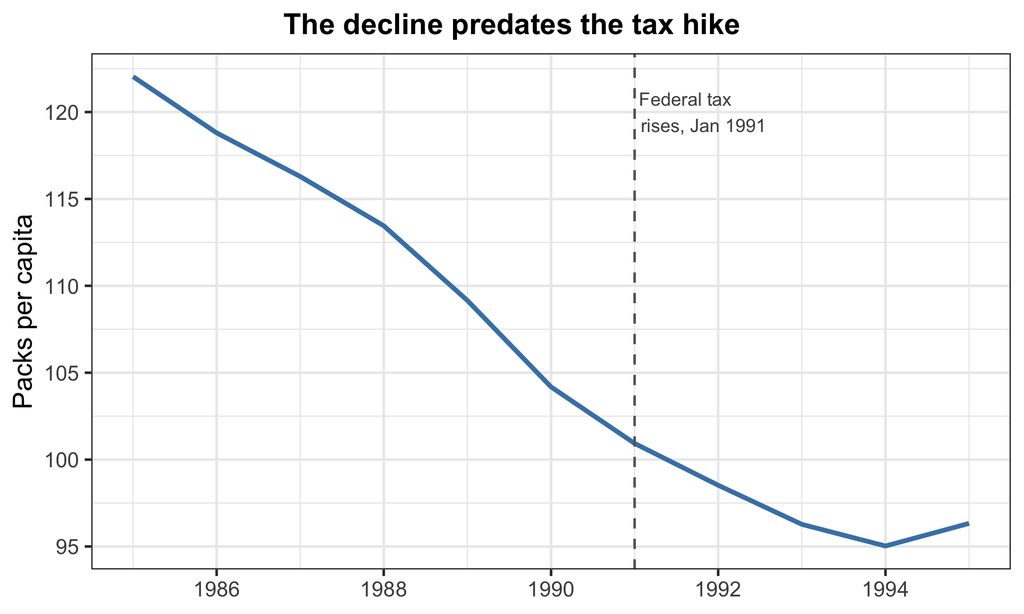

```r
national <- cigarettes |>
  group_by(year) |>
  summarize(mean_packs = mean(packpc)) |>
  mutate(date = make_date(year))

ggplot(national, aes(x = date, y = mean_packs)) +
  geom_line(color = "steelblue", linewidth = 1.1) +
  geom_vline(xintercept = make_date(1991),
             linetype = "dashed", color = "gray40") +
  scale_x_date(date_breaks = "2 years",
               date_labels = "%Y") +
  annotate("text", x = make_date(1991), y = 120,
           hjust = -0.05,
           size = 3.2, color = "gray30",
           label = "Federal tax\nrises, Jan 1991") +
  labs(title = "The decline predates the tax hike",
       x = NULL, y = "Packs per capita")
```

## A geom or `annotate()`?

`geom_text()` reads positions and labels from a data frame. `annotate()` uses constants you type. Use a geom for labels that belong to observations; use `annotate()` for a one-off note.

## Your Turn: label a reference line

*~3 minutes.* Add a horizontal line at the median of `ideo`, then label it with `annotate("text")`.

```r
# Fill in, then delete the eval:false line and re-render.
med <- median(states_2000$ideo)
ggplot(states_2000, aes(x = pid, y = ideo)) +
  geom_point(color = "gray60") +
  geom_hline(yintercept = ___, linetype = "dashed") +
  annotate("text", x = ___, y = med, label = ___) +
  labs(title = "State ideology and its median, 2000",
       x = "Partisanship (Dem - Rep)", y = "Ideology (Lib - Con)")
```

## Direct labels with ggrepel

Label only the states readers will ask about. ggrepel’s `geom_text_repel()` moves overlapping labels apart. `if_else()` keeps six abbreviations and gives the other states `NA_character_` (missing text), so they get no label. `%in%` tests membership, as in 03b.

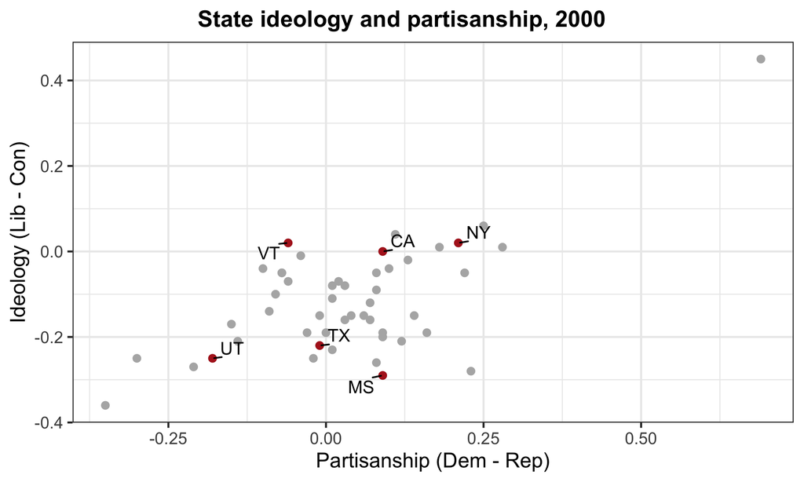

```r
show <- c("CA", "TX", "NY", "UT", "MS", "VT")
labeled <- states_2000 |>
  mutate(lab = if_else(st %in% show, st,
                       NA_character_))

ggplot(labeled, aes(x = pid, y = ideo)) +
  geom_point(color = "gray70") +
  geom_point(data = filter(labeled, !is.na(lab)),
             color = "firebrick") +
  geom_text_repel(aes(label = lab), seed = 42,
                  min.segment.length = 0) +
  labs(title =
         "State ideology and partisanship, 2000",
       x = "Partisanship (Dem - Rep)",
       y = "Ideology (Lib - Con)")
```

## Save it: ggsave

`ggsave()` writes a plot to a file. PNG works well in slides and Word; PDF is useful for print. Name the plot object and set the size in inches.

```r
ggsave("Plots/gap-example.png", plot = p, width = 8, height = 5, dpi = 300)
```

# Lab

## The cigarette plot starts here

Did consumption fall faster where real cigarette taxes rose? This plot has one line per state, which makes the two tax groups hard to compare. We hide the 48-entry legend.

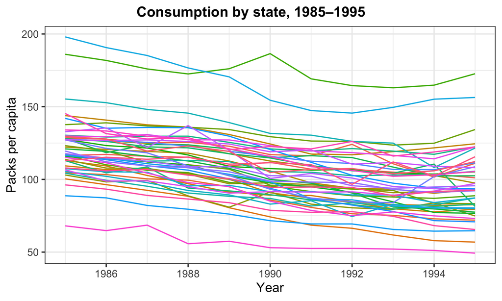

```r
ggplot(cigarettes,
       aes(x = date, y = packpc, color = state)) +
  geom_line() +
  scale_x_date(date_breaks = "2 years",
               date_labels = "%Y") +
  labs(title = "Consumption by state, 1985–1995",
       x = "Year", y = "Packs per capita") +
  theme(legend.position = "none")
```

## Lab: a two-line comparison

*5–10 minutes in class; finish by 7:00 PM Wednesday, September 30.* The workbook supplies the data comparison. Start the two-line plot in class, then finish the figure:

1. Plot the two tax-change groups in different colors.
2. Add the supplied direct end labels, a title stating the observed finding, and a source caption. Save the PNG.

Commit and push your progress before leaving, even if the figure is unfinished.

## Before Next Class

- **Project plan due Thursday, October 1 at 10:00 AM:** one page with your question, materials, intended analyses, and outputs. Request approval here if your project needs an alternative to the default data pipeline, first figure, or dashboard.
- **Finish** the makeover and render your workbook by 7:00 PM Wednesday, September 30; push the finished version and PNG. Your in-class progress commit still counts.
- No new reading. Thursday we turn this figure into a mini-paper: one source, many outputs, with cross-references and citations.

# If Time Remains

## Additional teaching and practice

These activities are optional. The lab doesn’t depend on them.

## Check the palette

Before publishing, check that groups remain distinguishable for readers with color-vision deficiencies and in grayscale. Okabe–Ito is a useful qualitative palette; viridis works well for ordered values.

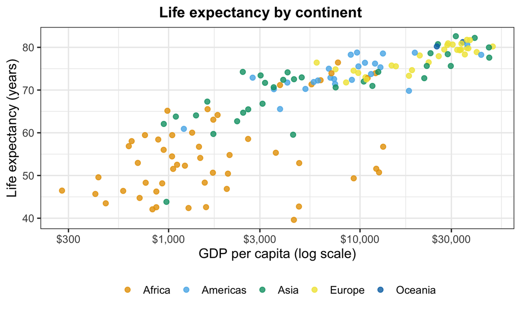

```r
okabe_ito <- c("#E69F00", "#56B4E9", "#009E73",
               "#F0E442", "#0072B2", "#D55E00",
               "#CC79A7", "#000000")

ggplot(gap_2007,
       aes(x = gdpPercap, y = lifeExp,
           color = continent)) +
  geom_point(alpha = 0.8, size = 2) +
  scale_x_log10(labels = label_dollar(accuracy = 1)) +
  scale_color_manual(values = okabe_ito) +
  labs(title = "Life expectancy by continent",
       x = "GDP per capita (log scale)",
       y = "Life expectancy (years)", color = NULL)
```

## Extension 1a: Same data, two impressions

*~8–10 minutes.*

Bars show amounts by their length, so the axis starts at zero. Each bar shows the unweighted mean life expectancy across countries in that continent.

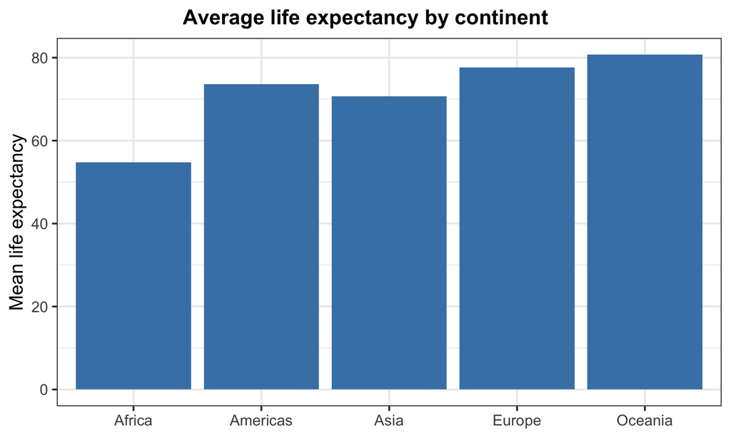

```r
life_by_continent <- gap_2007 |>
  group_by(continent) |>
  summarize(mean_life = mean(lifeExp))
ggplot(life_by_continent,
       aes(x = continent, y = mean_life)) +
  geom_col(fill = "steelblue") +
  labs(title = "Average life expectancy by continent",
       x = NULL, y = "Mean life expectancy")
```

## Extension 1b: Zoom the bars

Add `coord_cartesian(ylim = c(50, 85))` to the previous chunk. How many times longer does Europe’s bar look than Africa’s before and after the zoom? Would the same zoom mislead on a dot plot? Explain why the answer differs.

Problem Set 2 asks for exactly this kind of comparison on a figure of your own.